# Chapter2: Regression and model validation

# Chapter 2 - working with data / regression analysis

# Suvi Kivi 11.11.2018. This file shows what I have learned this week!

# ANALYSIS

## 1. Loading data in

```r
learning2014 <- read.csv("/Users/suvi/Documents/GitHub/IODS-project/Data/learning2014.csv")

dim(learning2014)
```

```
## [1] 166   8
```

```r
str (learning2014)
```

```
## 'data.frame':    166 obs. of  8 variables:
##  $ X       : int  1 2 3 4 5 6 7 8 9 10 ...
##  $ gender  : Factor w/ 2 levels "F","M": 1 2 1 2 2 1 2 1 2 1 ...
##  $ Age     : int  53 55 49 53 49 38 50 37 37 42 ...
##  $ Attitude: int  37 31 25 35 37 38 35 29 38 21 ...
##  $ deep    : num  3.58 2.92 3.5 3.5 3.67 ...
##  $ stra    : num  3.38 2.75 3.62 3.12 3.62 ...
##  $ surf    : num  2.58 3.17 2.25 2.25 2.83 ...
##  $ Points  : int  25 12 24 10 22 21 21 31 24 26 ...
```

Learning2014 dataset shows information about student, their attitudes and how they perform in tests. There are information about 166 students in the data and the variables are gender, age, attitude, deep, stra, surf and points. Gender and age are basic information about the student. Attitude shows students’ attitude towards statistics (many questions in the backround). Variables deep, stra and surf are collected together from different questions and the data shows the average of the Likert-scale (1-5). Variable points shows the students’ exam points.

## 2. graphical overview of the data

Graphical overwiev helps to understand the data. If we want to see the summaries of the variables, histogram is one way to see that.

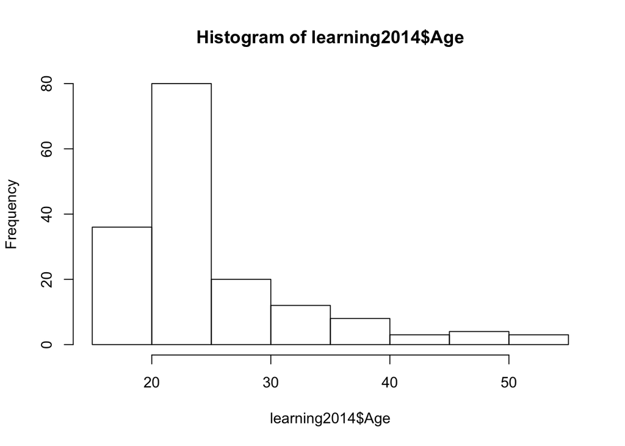

```r
hist_age <- hist(learning2014$Age)
```

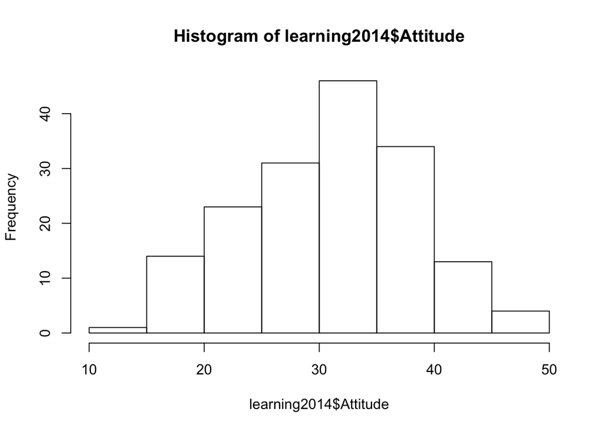

```r
hist_attitude <- hist(learning2014$Attitude)
```

Plots are also a good way to explore the data. For example we can see the points and the attitude in the same plot

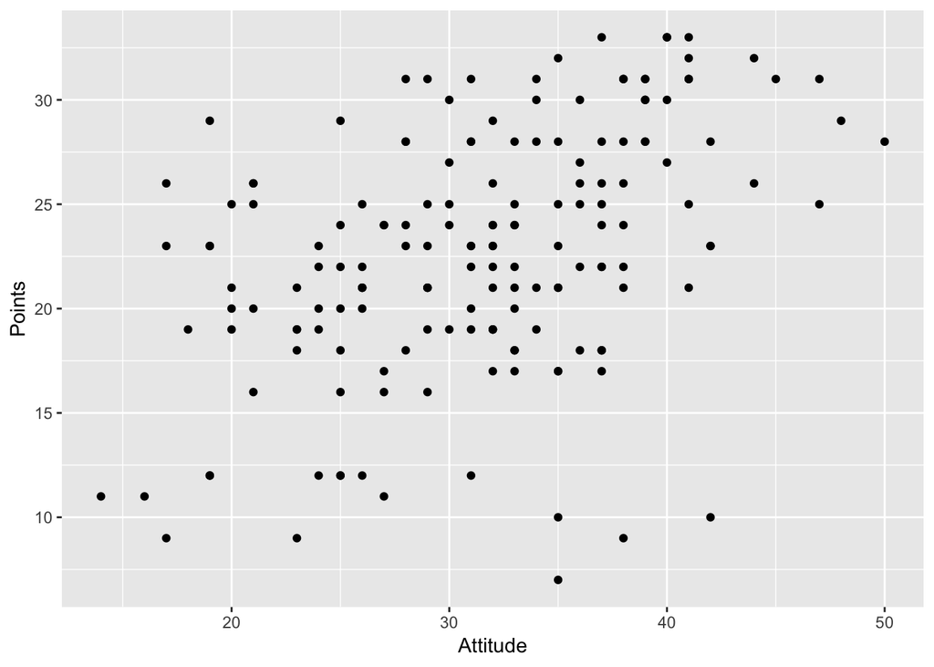

```r
library(ggplot2)

plot1 <- ggplot(learning2014, aes(x = Attitude, y = Points))

plot2 <- plot1 + geom_point()

plot2
```

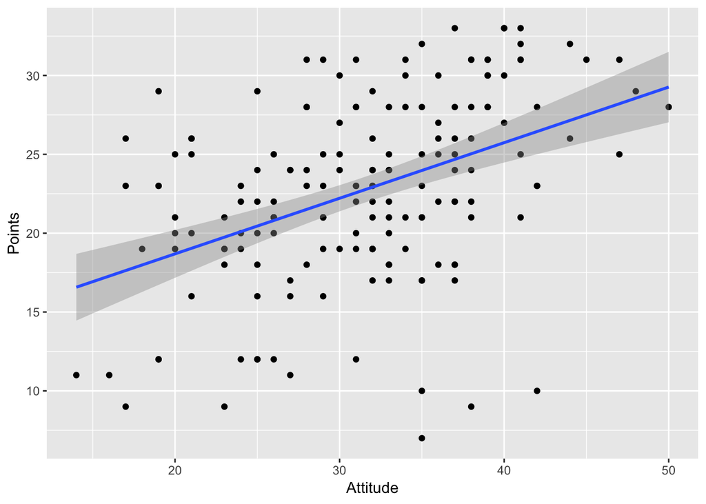

```r
plot3 <- plot2 + geom_smooth(method = "lm")

plot3
```

It seems that if the students attitude is higher the points are little bit higher too (we will test this later).

Also a good way to see data by all the variables, is to use pairs (pairs or for example ggpairs)

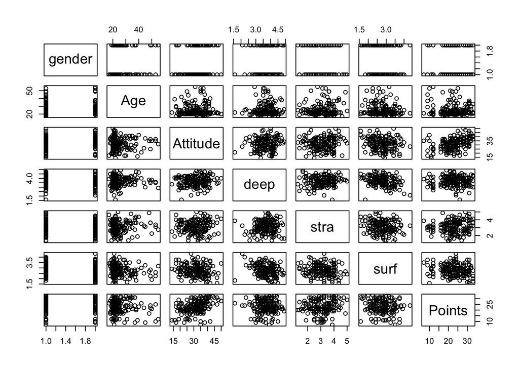

```r
pairs(learning2014[-1])
```

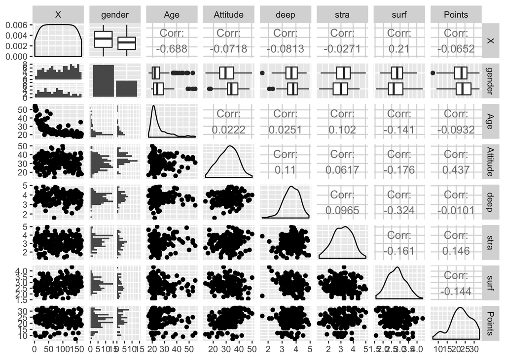

```r
library(GGally)

p <- ggpairs(learning2014, mapping = aes(), lower = list(combo = wrap("facethist", bins = 20)))

p
```

## 3. Choosing three explanatory variables -> regression analysis between attitude and points

Simple regression analysis: attitude and points

```r
keep_columns <- c("Age", "Attitude", "deep", "Points")

library(dplyr)
```

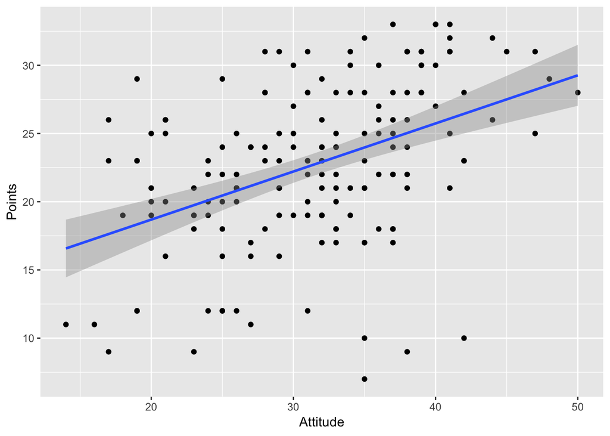

```r
variables <- select(learning2014, one_of(keep_columns))

qplot(Attitude, Points, data = variables) + geom_smooth(method = "lm")
```

```r
linear_model <- lm(Points ~ Attitude, data = variables)

summary (linear_model)
```

```
##
## Call:
## lm(formula = Points ~ Attitude, data = variables)
##
## Residuals:
##      Min       1Q   Median       3Q      Max
## -16.9763  -3.2119   0.4339   4.1534  10.6645
##
## Coefficients:
##             Estimate Std. Error t value Pr(>|t|)
## (Intercept) 11.63715    1.83035   6.358 1.95e-09 ***
## Attitude     0.35255    0.05674   6.214 4.12e-09 ***
## ---
## Signif. codes:  0 '***' 0.001 '**' 0.01 '*' 0.05 '.' 0.1 ' ' 1
##
## Residual standard error: 5.32 on 164 degrees of freedom
## Multiple R-squared:  0.1906, Adjusted R-squared:  0.1856
## F-statistic: 38.61 on 1 and 164 DF,  p-value: 4.119e-09
```

## 4. Summary of the models (simple and multiple models)

*Summary (linear_model)*

There is statistical relationship between points and attitude because P-value is smaller than 0,05 (4.119e-09). This means that if the attitude of the student is high, the student will more likely to have good points in test.

*Multiple regression analysis*

```r
linear_model2 <- lm(Points ~ Attitude + Age + deep, data = variables)

summary(linear_model2)
```

```
##
## Call:
## lm(formula = Points ~ Attitude + Age + deep, data = variables)
##
## Residuals:
##     Min      1Q  Median      3Q     Max
## -17.206  -3.430   0.204   3.979  10.950
##
## Coefficients:
##             Estimate Std. Error t value Pr(>|t|)
## (Intercept) 15.60773    3.38966   4.605 8.32e-06 ***
## Attitude     0.35941    0.05696   6.310 2.56e-09 ***
## Age         -0.07716    0.05322  -1.450    0.149
## deep        -0.60275    0.75031  -0.803    0.423
## ---
## Signif. codes:  0 '***' 0.001 '**' 0.01 '*' 0.05 '.' 0.1 ' ' 1
##
## Residual standard error: 5.307 on 162 degrees of freedom
## Multiple R-squared:  0.2043, Adjusted R-squared:  0.1896
## F-statistic: 13.87 on 3 and 162 DF,  p-value: 4.305e-08
```

There is statistical relationship between points and attitude but not with points and age/deep because of the p-values. This means that the age for example does not affect so much to test points, it is the attitude what matters the most.

## 5. Plots

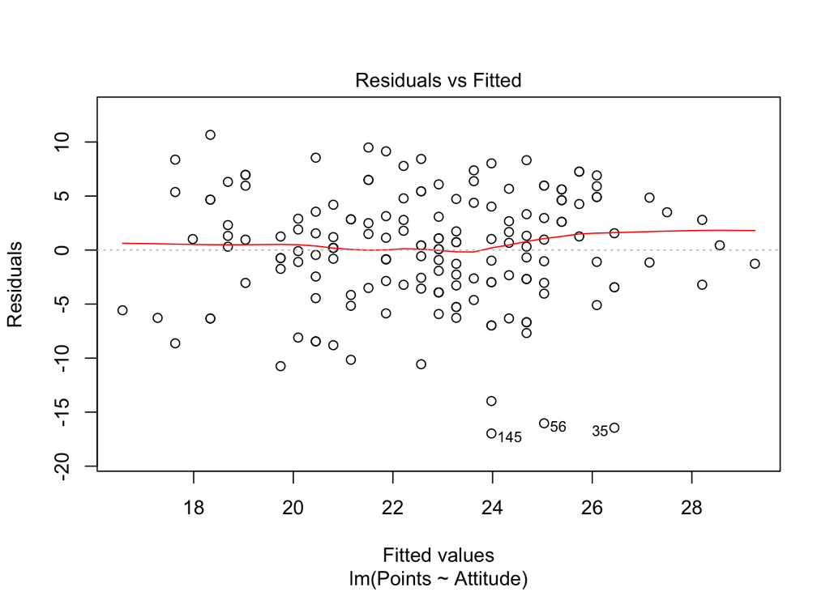

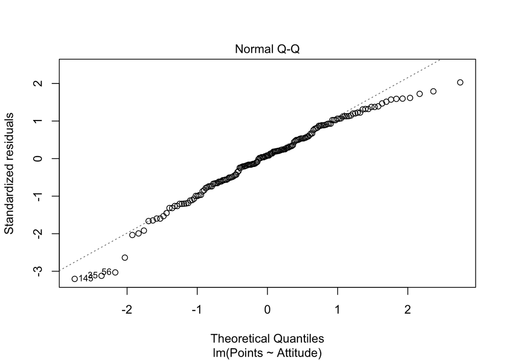

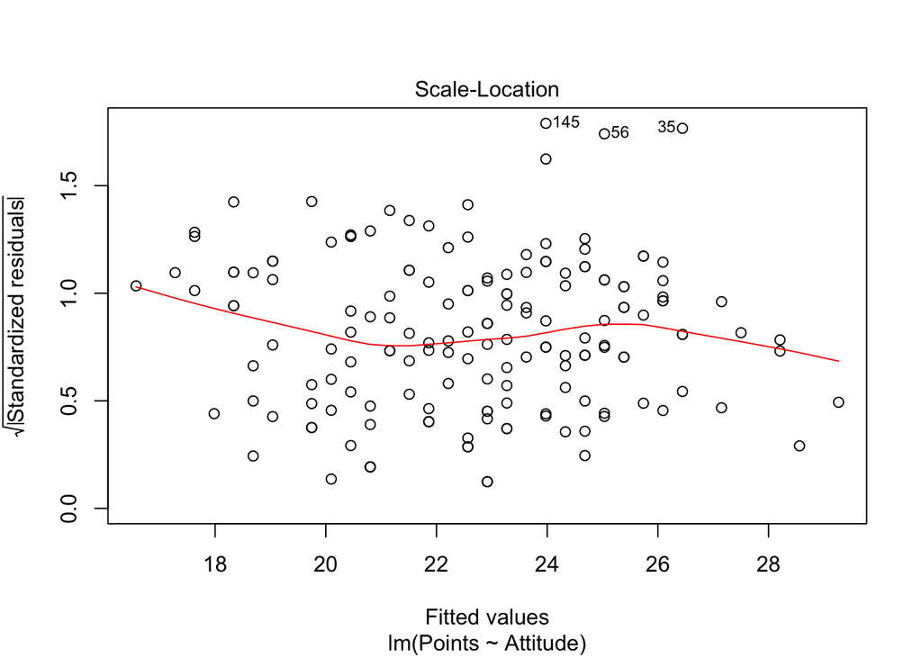

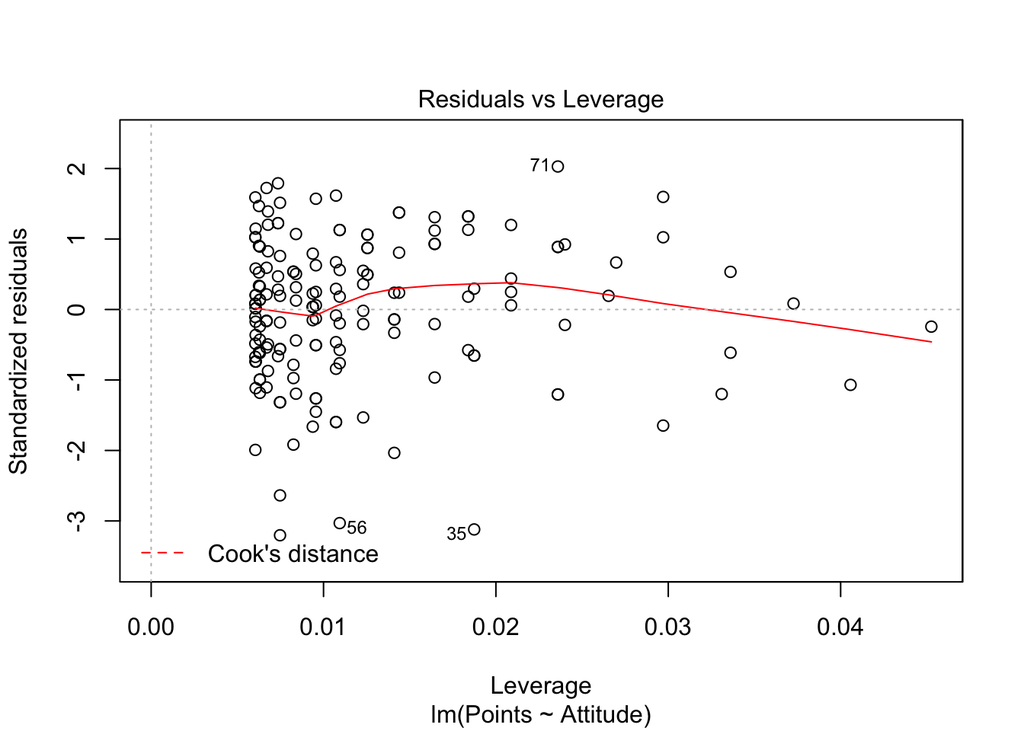

```r
plot(linear_model)
```

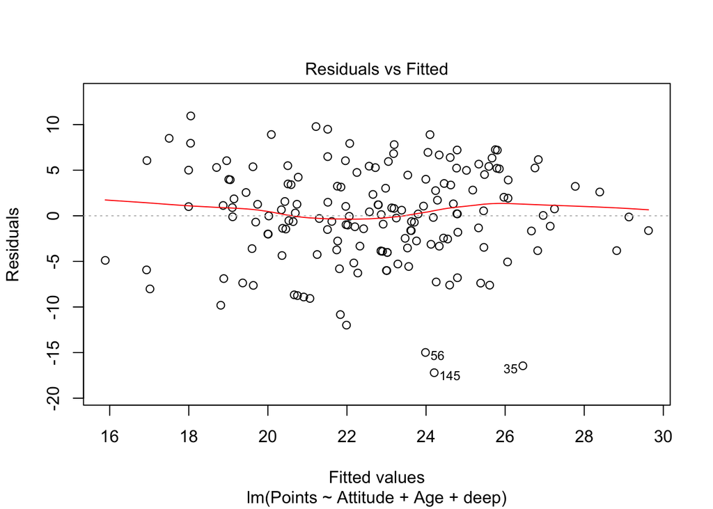

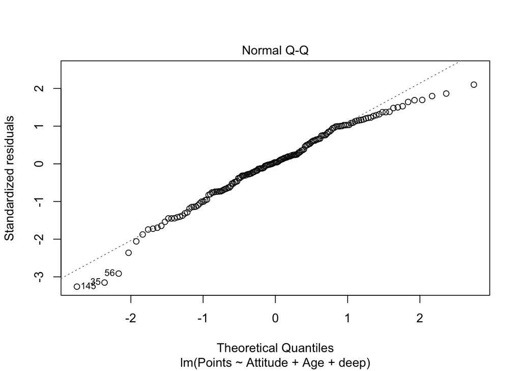

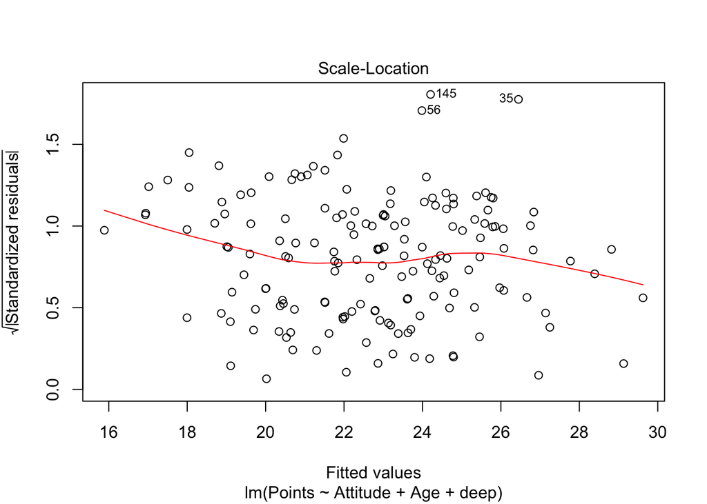

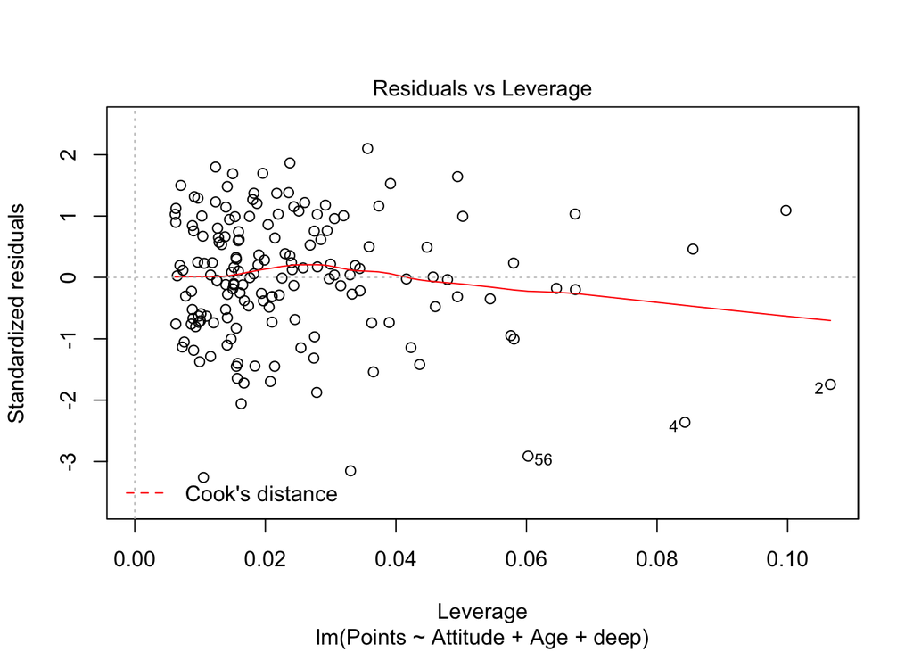

```r
plot(linear_model2)
```

From the plots you can see the residuals.